# Untitled

David Josephs

October 14, 2018

[output not shown]

[output not shown]

# The Data

```
##        BeerName Beer_ID   ABV IBU                               Style
## 1  Get Together    2692 0.045  50                        American IPA
## 2 Maggie's Leap    2691 0.049  26                  Milk / Sweet Stout
## 3    Wall's End    2690 0.048  19                   English Brown Ale
## 4       Pumpion    2689 0.060  38                         Pumpkin Ale
## 5    Stronghold    2688 0.060  25                     American Porter
## 6   Parapet ESB    2687 0.056  47 Extra Special / Strong Bitter (ESB)
##   Ounces        BreweryName Brewery_ID        City State
## 1     16 NorthGate Brewing           1 Minneapolis    MN
## 2     16 NorthGate Brewing           1 Minneapolis    MN
## 3     16 NorthGate Brewing           1 Minneapolis    MN
## 4     16 NorthGate Brewing           1 Minneapolis    MN
## 5     16 NorthGate Brewing           1 Minneapolis    MN
## 6     16 NorthGate Brewing           1 Minneapolis    MN
```

```
##                       BeerName Beer_ID   ABV IBU                   Style
## 2405             Pilsner Ukiah      98 0.055  NA         German Pilsener
## 2406  Heinnieweisse Weissebier      52 0.049  NA              Hefeweizen
## 2407           Snapperhead IPA      51 0.068  NA            American IPA
## 2408         Moo Thunder Stout      50 0.049  NA      Milk / Sweet Stout
## 2409         Porkslap Pale Ale      49 0.043  NA American Pale Ale (APA)
## 2410 Urban Wilderness Pale Ale      30 0.049  NA        English Pale Ale
##      Ounces                   BreweryName Brewery_ID          City State
## 2405     12         Ukiah Brewing Company        556         Ukiah    CA
## 2406     12       Butternuts Beer and Ale        557 Garrattsville    NY
## 2407     12       Butternuts Beer and Ale        557 Garrattsville    NY
## 2408     12       Butternuts Beer and Ale        557 Garrattsville    NY
## 2409     12       Butternuts Beer and Ale        557 Garrattsville    NY
## 2410     12 Sleeping Lady Brewing Company        558     Anchorage    AK
```

# Missing Values

```
##             na_count
## BeerName           0
## Beer_ID            0
## ABV               62
## IBU             1005
## Style              0
## Ounces             0
## BreweryName        0
## Brewery_ID         0
## City               0
## State              0
```

There are 62 missing data points for ABV, and 1005 missing data points for IBU.

# Map of numbers

[interactive chart not shown]

We can see that the Colorado has the darkest coloring on the graph which alludes to the highest number of breweries! Colorado contains 47 breweries. California, Oregon, Texas and Washington fall behind with 39, 29, 28, and 23 breweries.

# Map of IBU

[interactive chart not shown]

# Median IBU

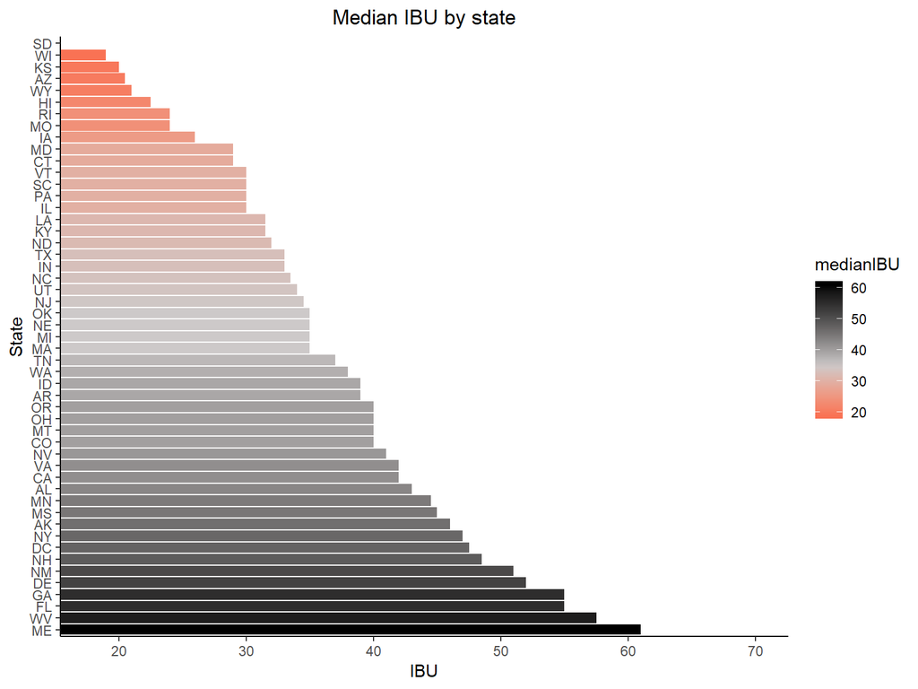

```
##   State                  BeerName    City IBU
## 1    OR Bitter Bitch Imperial IPA Astoria 138
```

Oregon has the bitterest beer of any state! Bitter Bitch Imperial IPA, produced in Astoria, has an IBU of 138! # Map of ABV

[interactive chart not shown]

# median ABV

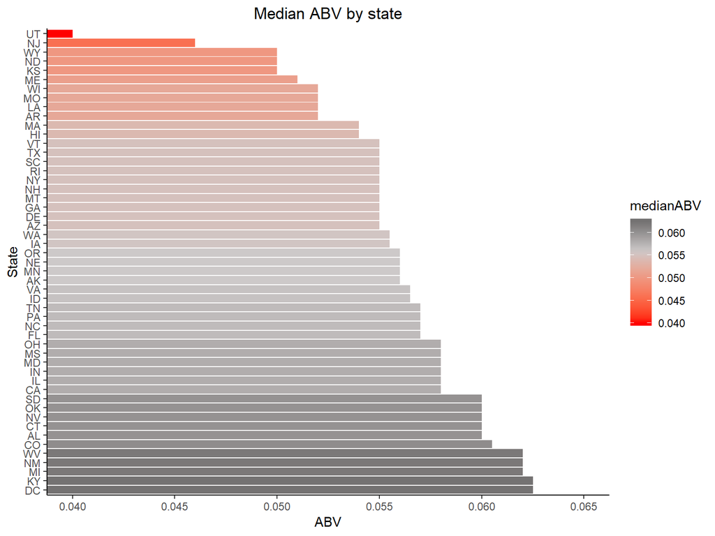

```
##   State                                             BeerName    City   ABV
## 1    CO Lee Hill Series Vol. 5 - Belgian Style Quadrupel Ale Boulder 0.128
```

Colorado has the most alcoholic beer of any state! Lee Hill Series Vol. 5, a Belgian Style Quadrupel Ale produced in Boulder,CO has an ABV of 12.8% # ABV vs IBU

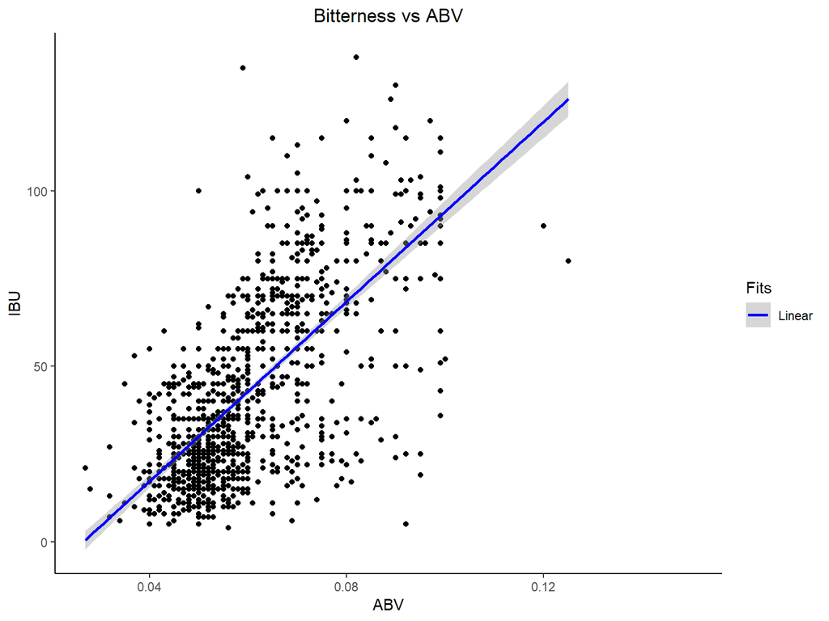

# More info on ABV

```
##    Min. 1st Qu.  Median    Mean 3rd Qu.    Max.    NA's
## 0.00100 0.05000 0.05600 0.05977 0.06700 0.12800      62
```